# Visualizing student schedules

Case study in solving problems with Polars and Altair

Eric Monson, PhD

Duke University Libraries  
Center for Data and Visualization Sciences

## Advisor Student Heatmaps

> Faculty need a quick way of summarizing busy and free times for the group of students they advise
- This ends up being a nice case study for using basic Polars  
  + visualization with Altair (the default plot module)
- Along the way I’ll review syntax and contrast with Pandas

## Where are we headed?

**Students’ schedules**

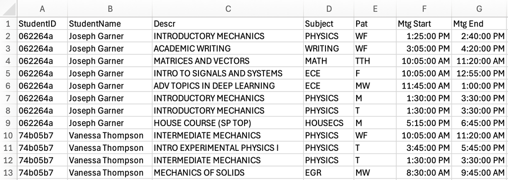

**Students’ advisors**

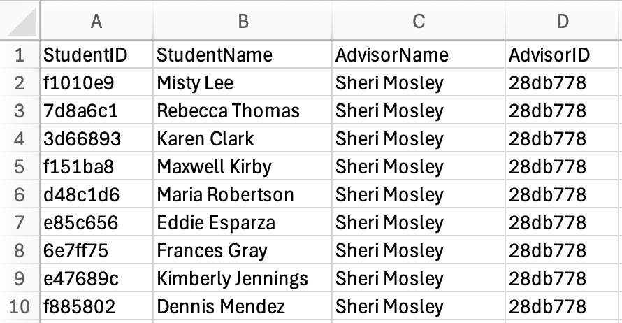

**All schedules/advisor**

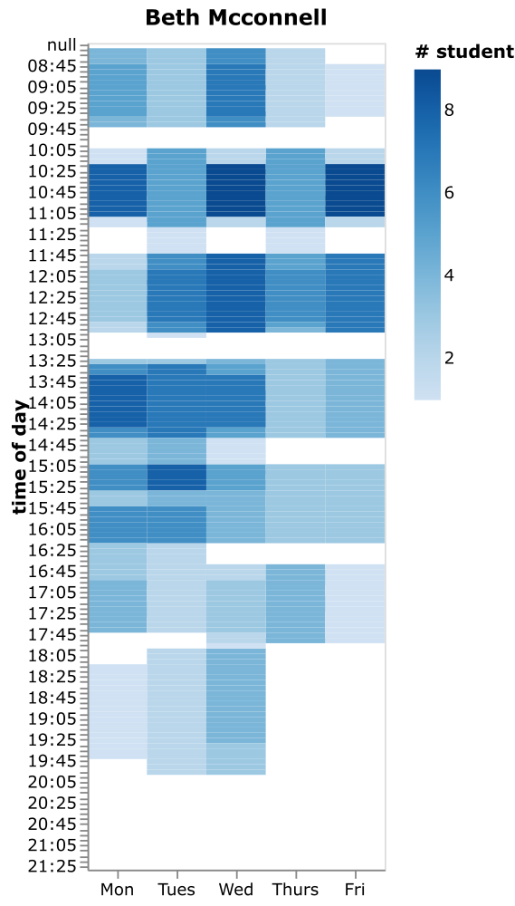

## Typical import of modules

```python
import polars as pl
import altair as alt
```

## Preview student schedules

```python
pl.read_csv('./data/students_deidentified.csv', n_rows=5)
```

shape: (5, 7)

| StudentID str | StudentName str | Descr str | Subject str | Pat str | Mtg Start str | Mtg End str |
| --- | --- | --- | --- | --- | --- | --- |
| "062264a" | "Joseph Garner" | "INTRODUCTORY MECHANICS" | "PHYSICS" | "WF" | "1:25:00 PM" | "2:40:00 PM" |
| "062264a" | "Joseph Garner" | "ACADEMIC WRITING" | "WRITING" | "WF" | "3:05:00 PM" | "4:20:00 PM" |
| "062264a" | "Joseph Garner" | "MATRICES AND VECTORS" | "MATH" | "TTH" | "10:05:00 AM" | "11:20:00 AM" |
| "062264a" | "Joseph Garner" | "INTRO TO SIGNALS AND SYSTEMS" | "ECE" | "F" | "10:05:00 AM" | "12:55:00 PM" |
| "062264a" | "Joseph Garner" | "ADV TOPICS IN DEEP LEARNING" | "ECE" | "MW" | "11:45:00 AM" | "1:00:00 PM" |

- Polars only supports UTF-8 text encoding for fast reads
- Not doing a lazy read/DataFrame here since the files aren’t big
- “Mtg Start” and “Mtg End” look like times but are strings right now
- If the IDs were integers we’d force them to be read as a strings  
  to not lose any leading zeros

## Full CSV read w/time conversion

```python
students_df = (pl.read_csv('./data/students_deidentified.csv')
                .with_columns(start=pl.col('Mtg Start').str.to_time('%r'),
                                end=pl.col('Mtg End').str.to_time('%r'))
                .drop(pl.col('Mtg Start','Mtg End'))
           )

print('Full DataFrame shape:', students_df.shape)
students_df.head(10)
```

```
Full DataFrame shape: (2976, 7)
```

shape: (10, 7)

| StudentID str | StudentName str | Descr str | Subject str | Pat str | start time | end time |
| --- | --- | --- | --- | --- | --- | --- |
| "062264a" | "Joseph Garner" | "INTRODUCTORY MECHANICS" | "PHYSICS" | "WF" | 13:25:00 | 14:40:00 |
| "062264a" | "Joseph Garner" | "ACADEMIC WRITING" | "WRITING" | "WF" | 15:05:00 | 16:20:00 |
| "062264a" | "Joseph Garner" | "MATRICES AND VECTORS" | "MATH" | "TTH" | 10:05:00 | 11:20:00 |
| "062264a" | "Joseph Garner" | "INTRO TO SIGNALS AND SYSTEMS" | "ECE" | "F" | 10:05:00 | 12:55:00 |
| "062264a" | "Joseph Garner" | "ADV TOPICS IN DEEP LEARNING" | "ECE" | "MW" | 11:45:00 | 13:00:00 |
| "062264a" | "Joseph Garner" | "INTRODUCTORY MECHANICS" | "PHYSICS" | "M" | 13:30:00 | 15:30:00 |
| "062264a" | "Joseph Garner" | "INTRODUCTORY MECHANICS" | "PHYSICS" | "T" | 13:30:00 | 15:30:00 |
| "062264a" | "Joseph Garner" | "HOUSE COURSE (SP TOP)" | "HOUSECS" | "M" | 17:15:00 | 18:45:00 |
| "74b05b7" | "Vanessa Thompson" | "INTERMEDIATE MECHANICS" | "PHYSICS" | "WF" | 10:05:00 | 11:20:00 |
| "74b05b7" | "Vanessa Thompson" | "INTRO EXPERIMENTAL PHYSICS I" | "PHYSICS" | "T" | 15:45:00 | 17:45:00 |

## Method chaining

```python
(pl.read_csv('./data/students_deidentified.csv')
    .with_columns(start=pl.col('Mtg Start').str.to_time('%r'),
                  end=pl.col('Mtg End').str.to_time('%r'))
    .drop(pl.col('Mtg Start','Mtg End'))
)
```

- Just chaining further processing onto `read_csv()`
- (…code…) alows breaks at dots

## Adding new columns

```python
(pl.read_csv('./data/students_deidentified.csv')
    .with_columns(start=pl.col('Mtg Start').str.to_time('%r'),
                  end=pl.col('Mtg End').str.to_time('%r'))
    .drop(pl.col('Mtg Start','Mtg End'))
)
```

- `.with_columns()` – adds new or modifies existing columns

## Adding new columns

```python
(pl.read_csv('./data/students_deidentified.csv')
    .with_columns(pl.col('Mtg Start').str.to_time('%r').alias('start'),
                  end=pl.col('Mtg End').str.to_time('%r'))
    .drop(pl.col('Mtg Start','Mtg End'))
)
```

- `.with_columns()` – adds new or modifies existing columns

## Naming your new columns

```python
(pl.read_csv('./data/students_deidentified.csv')
    .with_columns(pl.col('Mtg Start').str.to_time('%r').alias('start'),
                  end=pl.col('Mtg End').str.to_time('%r'))
    .drop(pl.col('Mtg Start','Mtg End'))
)
```

Two format options:

> `expression.alias('name')`  
> *or*  
> `name=expression`
- Second preferred for readability
- *Note: Python doesn’t allow “positional” arguments after “keyword” arguments*, so can’t use `.alias()` after `name=`

## Converting strings to times

```python
(pl.read_csv('./data/students_deidentified.csv')
    .with_columns(start=pl.col('Mtg Start').str.to_time('%r'),
                  end=pl.col('Mtg End').str.to_time('%r'))
    .drop(pl.col('Mtg Start','Mtg End'))
)
```

- We need formal `time` data type for later manipulation
- `.str.to_time()` [[format options documentation](https://docs.rs/chrono/latest/chrono/format/strftime/index.html)]
- `%r` is 12-hour time with AM/PM

## Dropping unnecessary columns

```python
(pl.read_csv('./data/students_deidentified.csv')
    .with_columns(start=pl.col('Mtg Start').str.to_time('%r'),
                  end=pl.col('Mtg End').str.to_time('%r'))
    .drop(pl.col('Mtg Start','Mtg End'))
)
```

- `.drop()` – only drops columns, unlike Pandas

## Existing column names

```python
(pl.read_csv('./data/students_deidentified.csv')
    .with_columns(start=pl.col('Mtg Start').str.to_time('%r'),
                  end=pl.col('Mtg End').str.to_time('%r'))
    .drop(pl.col('Mtg Start','Mtg End'))
)
```

Two format options:

> `pl.col('name')` ← *Polars expression*  
> *or*  
> `'name'` ← *plain string shortcut*
- First more flexible – the basis for building complex expressions
- First necessary for lazy evaluation, optimization, and parallel execution

## Read advisors DataFrame

```python
advisors_df = pl.read_csv('./data/advisors_deidentified.csv')
advisors_df
```

shape: (352, 4)

| StudentID str | StudentName str | AdvisorName str | AdvisorID str |
| --- | --- | --- | --- |
| "f1010e9" | "Misty Lee" | "Sheri Mosley" | "28db778" |
| "7d8a6c1" | "Rebecca Thomas" | "Sheri Mosley" | "28db778" |
| "3d66893" | "Karen Clark" | "Sheri Mosley" | "28db778" |
| "f151ba8" | "Maxwell Kirby" | "Sheri Mosley" | "28db778" |
| "d48c1d6" | "Maria Robertson" | "Sheri Mosley" | "28db778" |
| … | … | … | … |
| "fde1944" | "Gina Wolfe" | "Philip Gallagher" | "5cb893c" |
| "1315a19" | "Dalton Wu" | "Philip Gallagher" | "5cb893c" |
| "52fbc5f" | "Heidi Stafford" | "Philip Gallagher" | "5cb893c" |
| "13704ca" | "Neil Caldwell" | "Philip Gallagher" | "5cb893c" |
| "dc434aa" | "Brooke Whitney" | "Philip Gallagher" | "5cb893c" |

## JOIN students and advisors

- JOIN on StudentID
- StudentName is in both DataFrames so can drop one of them
- Filling *null* AdvisorName with placeholder string

```python
students_advisors_df = (
    students_df.join(advisors_df, on='StudentID', how='left')
          .drop(pl.col('StudentName_right'))
          .with_columns(pl.col('AdvisorName').fill_null(pl.lit('No Advisor')))
         )
students_advisors_df.sample(10)
```

shape: (10, 9)

| StudentID str | StudentName str | Descr str | Subject str | Pat str | start time | end time | AdvisorName str | AdvisorID str |
| --- | --- | --- | --- | --- | --- | --- | --- | --- |
| "74e6c83" | "Jill Roth" | "ACADEMIC WRITING" | "WRITING" | "MW" | 11:45:00 | 13:00:00 | "Destiny Terrell" | "a3aa6ec" |
| "e406134" | "Jeanne Taylor" | "ELEM DIFFERENTIAL EQUAT" | "MATH" | "TTH" | 13:25:00 | 14:40:00 | "Gilbert Higgins" | "f4dc685" |
| "32b817f" | "Donald Osborne" | "CORE CONCEPTS IN CHEMISTRY" | "CHEM" | "M" | 12:00:00 | 12:50:00 | "Candace Obrien" | "b3faa85" |
| "50cb8aa" | "Cynthia Woods" | "FINANCIAL ACCOUNTING" | "ECON" | "MWF" | 11:45:00 | 13:00:00 | "Hector Vaughn" | "2638532" |
| "659d13c" | "Jeremy Shelton" | "ACADEMIC WRITING" | "WRITING" | "TTH" | 13:25:00 | 14:40:00 | "Chad Reese" | "26c9a35" |
| "2478b6c" | "Peter Casey" | "INTRODUCTORY MECHANICS" | "PHYSICS" | "T" | 13:30:00 | 15:30:00 | "Dan Sims" | "eced0a0" |
| "00a233a" | "Julia Richards" | "INTRO EXPERIMENTAL PHYSICS I" | "PHYSICS" | "M" | 13:30:00 | 15:30:00 | "Gilbert Higgins" | "f4dc685" |
| "36d204f" | "Jermaine Carpenter" | "INTERMEDIATE MECHANICS" | "PHYSICS" | "T" | 15:45:00 | 17:45:00 | "Philip Gallagher" | "5cb893c" |
| "78c55f8" | "Adam Small" | "INTRODUCTORY MECHANICS" | "PHYSICS" | "T" | 15:45:00 | 17:45:00 | "Angie Moon" | "e7e131b" |
| "c68adc3" | "Kathryn Collins" | "PHYSICAL CHEMISTRY II" | "CHEM" | "TH" | 13:25:00 | 16:25:00 | "Chad Reese" | "26c9a35" |

# Exporatory aside

## Some students have no advisor

```python
(students_advisors_df
 .filter(pl.col('AdvisorName') == "No Advisor")
 .select(pl.col('StudentID','StudentName'))
 .unique()
)
```

shape: (22, 2)

| StudentID str | StudentName str |
| --- | --- |
| "a1964aa" | "Christian Stewart" |
| "de5e9c9" | "Jenny Reyes" |
| "2444c0d" | "Nicolas Holland" |
| "99c59cc" | "Bruce Pratt" |
| "8936d1c" | "Harold Watkins" |
| … | … |
| "67c5589" | "Julie Keller" |
| "a763934" | "Jim Fisher" |
| "95f9885" | "Austin Fischer" |
| "9d04ed2" | "Caitlin Adams" |
| "c299e53" | "Crystal Becker" |

## Filter returns subset of rows

```python
(students_advisors_df
 .filter(pl.col('AdvisorName') == "No Advisor")
 .select(pl.col('StudentID','StudentName'))
 .unique()
)
```

**`.filter()`**

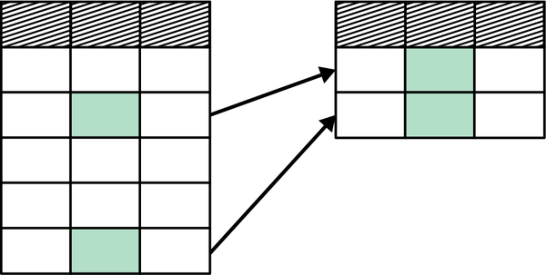

Images: Janssens, J., & Nieuwdorp, T. (2025). Python Polars: The Definitive Guide. O’Reilly Media.

## Select returns subset of columns

```python
(students_advisors_df
 .filter(pl.col('AdvisorName') == "No Advisor")
 .select(pl.col('StudentID','StudentName'))
 .unique()
)
```

**`.filter()`**

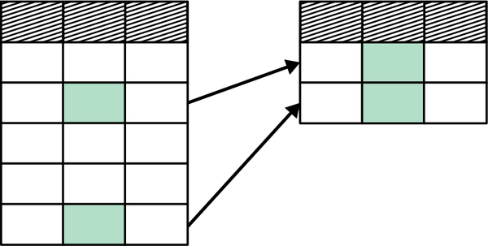

**`.select()`**

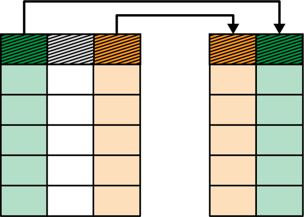

Images: Janssens, J., & Nieuwdorp, T. (2025). Python Polars: The Definitive Guide. O’Reilly Media.

## Unique removes repeated rows

```python
(students_advisors_df
 .filter(pl.col('AdvisorName') == "No Advisor")
 .select(pl.col('StudentID','StudentName'))
 .unique()
)
```

shape: (22, 2)

| StudentID str | StudentName str |
| --- | --- |
| "95f9885" | "Austin Fischer" |
| "de5e9c9" | "Jenny Reyes" |
| "42366d3" | "Kenneth Chandler" |
| "14aafd7" | "David Lewis" |
| "5fe5193" | "Daniel Miller" |
| … | … |
| "99c59cc" | "Bruce Pratt" |
| "8936d1c" | "Harold Watkins" |
| "630cfdd" | "Beverly Wright" |
| "2444c0d" | "Nicolas Holland" |
| "1ef6826" | "Brendan Dodson" |

## Some classes have no start time

```python
(students_advisors_df
 .filter(pl.col('start').is_null())
 .group_by(pl.col('Subject','Descr'))
 .agg(count = pl.col('StudentID').count())
 .sort('count', descending=True)
)
```

shape: (13, 3)

| Subject str | Descr str | count u32 |
| --- | --- | --- |
| "EGR" | "RESEARCH PROJECTS IN EGR" | 52 |
| "CEE" | "ENGINEERING THE PLANET" | 10 |
| "MUSIC" | "INTRO GUITAR CLASS" | 2 |
| "MUSIC" | "SYMPHONY ORCHESTRA" | 2 |
| "HLTHPOL" | "BASS CONNECTION HEALTH POLICY" | 1 |
| … | … | … |
| "MUSIC" | "WIND SYMPHONY" | 1 |
| "MUSIC" | "MEET THE BEATLES AND THE 1960S" | 1 |
| "MUSIC" | "THEOR/PRAC TONAL MUS I" | 1 |
| "MUSIC" | "CLARINET" | 1 |
| "ISS" | "INFORMATION, SOCIETY & CULTURE" | 1 |

## Filter to null start time

```python
(students_advisors_df
 .filter(pl.col('start').is_null())
 .group_by(pl.col('Subject','Descr'))
 .agg(count = pl.col('StudentID').count())
 .sort('count', descending=True)
)
```

- Remember, `.filter()` lets through what is `True`

## Group by Subject & Description

```python
(students_advisors_df
 .filter(pl.col('start').is_null())
 .group_by(pl.col('Subject','Descr'))
 .agg(count = pl.col('StudentID').count())
 .sort('count', descending=True)
)
```

- Get a separate group for each unique combination of the two variables
- Unlike Pandas
  - `.group_by()` returns grouping variables as normal columns
  - There is no `Index` in Polars DataFrames

## Aggregate by count of ID

```python
(students_advisors_df
 .filter(pl.col('start').is_null())
 .group_by(pl.col('Subject','Descr'))
 .agg(count = pl.col('StudentID').count())
 .sort('count', descending=True)
)
```

- Perform this aggregation on each group
- Could put more expressions in `.agg()` separated by commas

## Sort by count, descending

```python
(students_advisors_df
 .filter(pl.col('start').is_null())
 .group_by(pl.col('Subject','Descr'))
 .agg(count = pl.col('StudentID').count())
 .sort('count', descending=True)
)
```

- Ascending sort order is the default
- *Note: Pandas is opposite for descending: `ascending=False`*

## Some classes have no start time

```python
(students_advisors_df
 .filter(pl.col('start').is_null())
 .group_by(pl.col('Subject','Descr'))
 .agg(count = pl.col('StudentID').count())
 .sort('count', descending=True)
)
```

shape: (13, 3)

| Subject str | Descr str | count u32 |
| --- | --- | --- |
| "EGR" | "RESEARCH PROJECTS IN EGR" | 52 |
| "CEE" | "ENGINEERING THE PLANET" | 10 |
| "MUSIC" | "INTRO GUITAR CLASS" | 2 |
| "MUSIC" | "SYMPHONY ORCHESTRA" | 2 |
| "MUSIC" | "WIND SYMPHONY" | 1 |
| … | … | … |
| "MUSIC" | "CLARINET" | 1 |
| "ISS" | "INFORMATION, SOCIETY & CULTURE" | 1 |
| "MUSIC" | "FLUTE" | 1 |
| "MUSIC" | "SAXOPHONE" | 1 |
| "MUSIC" | "MEET THE BEATLES AND THE 1960S" | 1 |

# Back to data prep

## Dealing with days of the week

| StudentID | StudentName | Descr | Subject | Pat | start | end | AdvisorName | AdvisorID |
| --- | --- | --- | --- | --- | --- | --- | --- | --- |
| 062264a | Joseph Garner | INTRODUCTORY MECHANICS | PHYSICS | WF | 13:25:00 | 14:40:00 | Henry Schroeder | e6d6592 |
| 062264a | Joseph Garner | ACADEMIC WRITING | WRITING | WF | 15:05:00 | 16:20:00 | Henry Schroeder | e6d6592 |
| 062264a | Joseph Garner | MATRICES AND VECTORS | MATH | TTH | 10:05:00 | 11:20:00 | Henry Schroeder | e6d6592 |
| 062264a | Joseph Garner | INTRO TO SIGNALS AND SYSTEMS | ECE | F | 10:05:00 | 12:55:00 | Henry Schroeder | e6d6592 |
| 062264a | Joseph Garner | ADV TOPICS IN DEEP LEARNING | ECE | MW | 11:45:00 | 13:00:00 | Henry Schroeder | e6d6592 |
| 062264a | Joseph Garner | INTRODUCTORY MECHANICS | PHYSICS | M | 13:30:00 | 15:30:00 | Henry Schroeder | e6d6592 |
| 062264a | Joseph Garner | INTRODUCTORY MECHANICS | PHYSICS | T | 13:30:00 | 15:30:00 | Henry Schroeder | e6d6592 |
| 062264a | Joseph Garner | HOUSE COURSE (SP TOP) | HOUSECS | M | 17:15:00 | 18:45:00 | Henry Schroeder | e6d6592 |
| 74b05b7 | Vanessa Thompson | INTERMEDIATE MECHANICS | PHYSICS | WF | 10:05:00 | 11:20:00 | Dan Sims | eced0a0 |
| 74b05b7 | Vanessa Thompson | INTRO EXPERIMENTAL PHYSICS I | PHYSICS | T | 15:45:00 | 17:45:00 | Dan Sims | eced0a0 |

- Need to spell out days of the week for the visualization
- One day per row in the DataFrame for aggregation

## *Aside: styling with `great_tables`*

```python
from great_tables import loc, style

(students_advisors_df.head(6).style
    .tab_style(
        style=[style.text(weight='bold'), style.fill("#FCF7E5")],
        locations=loc.body(columns="Pat")
    )
)
```

| StudentID | StudentName | Descr | Subject | Pat | start | end | AdvisorName | AdvisorID |
| --- | --- | --- | --- | --- | --- | --- | --- | --- |
| 062264a | Joseph Garner | INTRODUCTORY MECHANICS | PHYSICS | WF | 13:25:00 | 14:40:00 | Henry Schroeder | e6d6592 |
| 062264a | Joseph Garner | ACADEMIC WRITING | WRITING | WF | 15:05:00 | 16:20:00 | Henry Schroeder | e6d6592 |
| 062264a | Joseph Garner | MATRICES AND VECTORS | MATH | TTH | 10:05:00 | 11:20:00 | Henry Schroeder | e6d6592 |
| 062264a | Joseph Garner | INTRO TO SIGNALS AND SYSTEMS | ECE | F | 10:05:00 | 12:55:00 | Henry Schroeder | e6d6592 |
| 062264a | Joseph Garner | ADV TOPICS IN DEEP LEARNING | ECE | MW | 11:45:00 | 13:00:00 | Henry Schroeder | e6d6592 |
| 062264a | Joseph Garner | INTRODUCTORY MECHANICS | PHYSICS | M | 13:30:00 | 15:30:00 | Henry Schroeder | e6d6592 |

Styling docs: https://docs.pola.rs/user-guide/misc/styling/

## Explicitly define day lookup patterns

- Decide whether you want the *full* or *abbreviated* forms of the weekdays in the vis

```python
days_version = "Abbreviation"
# days_version = "Full"

classdays_abbrev_dict = {'TTH':['Tues','Thurs'],
                  'MW':['Mon','Wed'],
                  'MTW':['Mon','Tues','Wed'],
                  'MTTH':['Mon','Tues','Thurs'],
                  'M':['Mon'],
                  'WF':['Wed','Fri'],
                  'F':['Fri'],
                  'TH':['Thurs'],
                  'MWF':['Mon','Wed','Fri'],
                  'MTH':['Mon','Thurs'],
                  'MTWF':['Mon','Tues','Wed','Fri'],
                  'MF':['Mon','Fri'],
                  'M-TH':['Mon','Tues','Wed','Thurs'],
                  'M-F':['Mon','Tues','Wed','Thurs','Fri'],
                  'T':['Tues'],
                  'MT':['Mon','Tues'],
                  'W':['Wed'],
                  'TF':['Tues','Fri']}

classdays_full_dict = {'TTH':['Tuesday','Thursday'],
                  'MW':['Monday','Wednesday'],
                  'MTW':['Monday','Tuesday','Wednesday'],
                  'MTTH':['Monday','Tuesday','Thursday'],
                  'M':['Monday'],
                  'WF':['Wednesday','Friday'],
                  'F':['Friday'],
                  'TH':['Thursday'],
                  'MWF':['Monday','Wednesday','Friday'],
                  'MTH':['Monday','Thursday'],
                  'MTWF':['Monday','Tuesday','Wednesday','Friday'],
                  'MF':['Monday','Friday'],
                  'M-TH':['Monday','Tuesday','Wednesday','Thursday'],
                  'M-F':['Monday','Tuesday','Wednesday','Thursday','Friday'],
                  'T':['Tuesday'],
                  'MT':['Monday','Tuesday'],
                  'W':['Wednesday'],
                  'TF':['Tuesday','Friday']}

if days_version.lower() == "abbreviation":
    classdays_dict = classdays_abbrev_dict
else:
    classdays_dict = classdays_full_dict
```

## Parsing for day pattern lookups

- This version adapts to the patterns present (better for new data but not more readable)

```python
# days_version = "full"
days_version = "abbreviation"

days_letters = ['M', 'T', 'W', 'H', 'F']
days_list_full = ['Monday', 'Tuesday', 'Wednesday', 'Thursday', 'Friday']
days_list_abbrev = ['Mon', 'Tues', 'Wed', 'Thurs', 'Fri']

# Using Pandas Series so can use slice notation on day ranges with dashes
if days_version.lower() == "full":
    classdays_series = pd.Series(dict(zip(days_letters, days_list_full)))
else:
    classdays_series = pd.Series(dict(zip(days_letters, days_list_abbrev)))

classdays_dict = {}
for day_pattern in students_advisors_df.get_column('Pat').unique().to_list():
    if day_pattern is not None:                             # There are some null day patterns
        day_pattern_noTH = day_pattern.replace('TH','H')    # Thurs only two-character abbrev
        if '-' in day_pattern_noTH:
            # Handle patterns like 'M-W', 'T-H', etc.
            match = re.search(r'([A-Z])-([A-Z])', day_pattern_noTH)
            classdays_dict[day_pattern] = classdays_series[slice(match.group(1),match.group(2))].to_list()
        else:
            # Handle single day patterns like 'MWF', 'TTH', etc.
            classdays_dict[day_pattern] = classdays_series[list(day_pattern_noTH)].to_list()


classdays_dict
```

## Parsing for day pattern lookups

```
{'TTH': ['Tues', 'Thurs'],
 'MF': ['Mon', 'Fri'],
 'W': ['Wed'],
 'MTTH': ['Mon', 'Tues', 'Thurs'],
 'MW': ['Mon', 'Wed'],
 'M': ['Mon'],
 'F': ['Fri'],
 'MWF': ['Mon', 'Wed', 'Fri'],
 'WF': ['Wed', 'Fri'],
 'TH': ['Thurs'],
 'T': ['Tues']}
```

## Test the day range replacements

```python
students_advisors_df.select(pl.col('Pat'),
                            weekday=pl.col('Pat').replace_strict(classdays_dict))
```

shape: (2_976, 2)

| Pat str | weekday list[str] |
| --- | --- |
| "WF" | ["Wed", "Fri"] |
| "WF" | ["Wed", "Fri"] |
| "TTH" | ["Tues", "Thurs"] |
| "F" | ["Fri"] |
| "MW" | ["Mon", "Wed"] |
| … | … |
| "T" | ["Tues"] |
| "TTH" | ["Tues", "Thurs"] |
| "MW" | ["Mon", "Wed"] |
| "W" | ["Wed"] |
| "TTH" | ["Tues", "Thurs"] |

## Replace and explode into rows

- Other columns get repeated

```python
sa_w_weekdays = (students_advisors_df
           .with_columns(weekday=pl.col('Pat').replace_strict(classdays_dict))
           .explode('weekday')
         )
sa_w_weekdays.select(pl.col('StudentName','Descr','Pat','weekday'))
```

shape: (4_624, 4)

| StudentName str | Descr str | Pat str | weekday str |
| --- | --- | --- | --- |
| "Joseph Garner" | "INTRODUCTORY MECHANICS" | "WF" | "Wed" |
| "Joseph Garner" | "INTRODUCTORY MECHANICS" | "WF" | "Fri" |
| "Joseph Garner" | "ACADEMIC WRITING" | "WF" | "Wed" |
| "Joseph Garner" | "ACADEMIC WRITING" | "WF" | "Fri" |
| "Joseph Garner" | "MATRICES AND VECTORS" | "TTH" | "Tues" |
| … | … | … | … |
| "Judith Norris" | "ADV TOPICS IN DEEP LEARNING" | "MW" | "Mon" |
| "Judith Norris" | "ADV TOPICS IN DEEP LEARNING" | "MW" | "Wed" |
| "Judith Norris" | "INTRO TO SIGNALS AND SYSTEMS" | "W" | "Wed" |
| "Judith Norris" | "MATRICES AND VECTORS" | "TTH" | "Tues" |
| "Judith Norris" | "MATRICES AND VECTORS" | "TTH" | "Thurs" |

## Test `time_ranges()`

- Make list of times between “start” and “end”
- Decided to set `closed='left'` so don’t include the end time in list

## Test `time_ranges()`

- Make list of times between “start” and “end”
- Decided to set `closed='left'` so don’t include the end time in list

```python
(sa_w_weekdays
 .with_columns(Time=pl.time_ranges("start", "end", interval='5m', closed='left'))
 .select(pl.col('StudentName','weekday','start','end','Time'))
)
```

shape: (4_624, 5)

| StudentName str | weekday str | start time | end time | Time list[time] |
| --- | --- | --- | --- | --- |
| "Joseph Garner" | "Wed" | 13:25:00 | 14:40:00 | [13:25:00, 13:30:00, … 14:35:00] |
| "Joseph Garner" | "Fri" | 13:25:00 | 14:40:00 | [13:25:00, 13:30:00, … 14:35:00] |
| "Joseph Garner" | "Wed" | 15:05:00 | 16:20:00 | [15:05:00, 15:10:00, … 16:15:00] |
| "Joseph Garner" | "Fri" | 15:05:00 | 16:20:00 | [15:05:00, 15:10:00, … 16:15:00] |
| "Joseph Garner" | "Tues" | 10:05:00 | 11:20:00 | [10:05:00, 10:10:00, … 11:15:00] |
| … | … | … | … | … |
| "Judith Norris" | "Mon" | 15:05:00 | 16:20:00 | [15:05:00, 15:10:00, … 16:15:00] |
| "Judith Norris" | "Wed" | 15:05:00 | 16:20:00 | [15:05:00, 15:10:00, … 16:15:00] |
| "Judith Norris" | "Wed" | 10:05:00 | 12:55:00 | [10:05:00, 10:10:00, … 12:50:00] |
| "Judith Norris" | "Tues" | 08:30:00 | 09:45:00 | [08:30:00, 08:35:00, … 09:40:00] |
| "Judith Norris" | "Thurs" | 08:30:00 | 09:45:00 | [08:30:00, 08:35:00, … 09:40:00] |

## Explode time ranges into rows

- Make list of times between “start” and “end”
- Decided to set `closed='left'` so don’t include the end time in list

```python
(sa_w_weekdays
 .with_columns(Time=pl.time_ranges("start", "end", interval='5m', closed='left'))
 .select(pl.col('StudentName','weekday','start','end','Time'))
 .explode('Time')
)
```

shape: (75_247, 5)

| StudentName str | weekday str | start time | end time | Time time |
| --- | --- | --- | --- | --- |
| "Joseph Garner" | "Wed" | 13:25:00 | 14:40:00 | 13:25:00 |
| "Joseph Garner" | "Wed" | 13:25:00 | 14:40:00 | 13:30:00 |
| "Joseph Garner" | "Wed" | 13:25:00 | 14:40:00 | 13:35:00 |
| "Joseph Garner" | "Wed" | 13:25:00 | 14:40:00 | 13:40:00 |
| "Joseph Garner" | "Wed" | 13:25:00 | 14:40:00 | 13:45:00 |
| … | … | … | … | … |
| "Judith Norris" | "Thurs" | 08:30:00 | 09:45:00 | 09:20:00 |
| "Judith Norris" | "Thurs" | 08:30:00 | 09:45:00 | 09:25:00 |
| "Judith Norris" | "Thurs" | 08:30:00 | 09:45:00 | 09:30:00 |
| "Judith Norris" | "Thurs" | 08:30:00 | 09:45:00 | 09:35:00 |
| "Judith Norris" | "Thurs" | 08:30:00 | 09:45:00 | 09:40:00 |

## Time back to string for visualization

```python
class_day_time_df = (
    sa_w_weekdays
     .with_columns(Time=pl.time_ranges("start", "end", interval='5m', closed='left'))
     .explode('Time')
     .select(pl.col('Time').dt.strftime("%H:%M"),
             pl.col('weekday').alias('Day'),
             pl.col('Descr').alias('Class'),
             pl.col('StudentName'),
             pl.col('AdvisorName')
            )
)

class_day_time_df
```

- Altair doesn’t support the Polars “time” data type
- Only keep the columns we’ll need for the visualization
  - Using the `.alias()` form in `.select()` since prefer this column order and can’t put “positional” arguments after “keyword” ones

## Time back to string for visualization

shape: (75_247, 5)

| Time str | Day str | Class str | StudentName str | AdvisorName str |
| --- | --- | --- | --- | --- |
| "13:25" | "Wed" | "INTRODUCTORY MECHANICS" | "Joseph Garner" | "Henry Schroeder" |
| "13:30" | "Wed" | "INTRODUCTORY MECHANICS" | "Joseph Garner" | "Henry Schroeder" |
| "13:35" | "Wed" | "INTRODUCTORY MECHANICS" | "Joseph Garner" | "Henry Schroeder" |
| "13:40" | "Wed" | "INTRODUCTORY MECHANICS" | "Joseph Garner" | "Henry Schroeder" |
| "13:45" | "Wed" | "INTRODUCTORY MECHANICS" | "Joseph Garner" | "Henry Schroeder" |
| … | … | … | … | … |
| "09:20" | "Thurs" | "MATRICES AND VECTORS" | "Judith Norris" | "Angie Moon" |
| "09:25" | "Thurs" | "MATRICES AND VECTORS" | "Judith Norris" | "Angie Moon" |
| "09:30" | "Thurs" | "MATRICES AND VECTORS" | "Judith Norris" | "Angie Moon" |
| "09:35" | "Thurs" | "MATRICES AND VECTORS" | "Judith Norris" | "Angie Moon" |
| "09:40" | "Thurs" | "MATRICES AND VECTORS" | "Judith Norris" | "Angie Moon" |

## Lists for visualization

- Need an ordered list of times for the vis row ordering
- List of weekday names sets the vis column order
- List of advisors we will facet by

```python
times_list = (class_day_time_df
 .get_column('Time')
 .unique()
 .sort()
 .to_list()
)
# Look at a few entries...
print(times_list[:5])

# Sets the visualization column order
if days_version.lower()=="abbreviation":
    days_list = ['Mon', 'Tues', 'Wed', 'Thurs', 'Fri']
else:
    days_list = ['Monday','Tuesday','Wednesday','Thursday','Friday']

advisors_list = (class_day_time_df
 .get_column('AdvisorName')
 .unique()
 .sort()
 .to_list()
)
print('There are', len(advisors_list), 'advisors')
```

```
[None, '08:30', '08:35', '08:40', '08:45']
There are 27 advisors
```

# Visualization

## Visualization

- Finally! :-)
- Grouping and aggregation done in Polars so:
  - not too many data rows in Altair
  - faster
    - Altair has built-in aggregation
    - It’s not very fast
    - VegaFusion helps with speed + number of rows issue

[figure not shown]

https://altair-viz.github.io

## Start with a single advisor

```python
advisor = advisors_list[1]
print(advisor)
```

```
Beth Mcconnell
```

## DataFrame for a single advisor

```python
single_advisor_df = (
  class_day_time_df
    .filter(pl.col('AdvisorName') == advisor)
    .group_by(pl.col('AdvisorName','Day','Time'))
    .agg(Count=pl.col('Class').count(),
         Students=pl.col('StudentName').str.join('; '))
)

single_advisor_df.select(
    pl.all().exclude('AdvisorName')
    )
```

shape: (542, 4)

| Day str | Time str | Count u32 | Students str |
| --- | --- | --- | --- |
| "Mon" | "08:45" | 5 | "Lori Bennett; Francisco Juarez… |
| "Fri" | "17:50" | 1 | "Taylor Freeman" |
| "Thurs" | "09:40" | 2 | "Taylor Freeman; Joanne Torres" |
| "Thurs" | "15:25" | 3 | "Christy Curry; Taylor Freeman;… |
| "Fri" | "14:05" | 4 | "Ralph Hernandez; Francisco Jua… |
| … | … | … | … |
| "Mon" | "16:55" | 4 | "Lori Bennett; Ralph Hernandez;… |
| "Fri" | "12:45" | 7 | "Lori Bennett; Wendy Barr; Ralp… |
| "Wed" | "13:40" | 7 | "Lori Bennett; Wendy Barr; Ralp… |
| "Wed" | "17:20" | 3 | "Lori Bennett; Taylor Freeman; … |
| "Fri" | "09:05" | 1 | "Mathew Glass" |

## Using Altair for a single advisor

```python
single_advisor_df = (
  class_day_time_df
    .filter(pl.col('AdvisorName') == advisor)
    .group_by(pl.col('AdvisorName','Day','Time'))
    .agg(Count=pl.col('Class').count(),
         Students=pl.col('StudentName').str.join('; '))
)

single_advisor_df.plot.rect(
    x='Day',
    y='Time',
    color='Count',
    tooltip=['Day','Time','Count','Students']
)
```

[interactive chart not shown]

## Using Altair for a single advisor

```python
single_advisor_df = (
  class_day_time_df
    .filter(pl.col('AdvisorName') == advisor)
    .group_by(pl.col('AdvisorName','Day','Time'))
    .agg(Count=pl.col('Class').count(),
         Students=pl.col('StudentName').str.join('; '))
)

single_advisor_df.plot.rect(
    x='Day:O',
    y='Time:O',
    color='Count:Q',
    tooltip=['Day','Time','Count','Students']
).properties(
        width=180,
        height=500
)
```

[interactive chart not shown]

## Using Altair for a single advisor

```python
(class_day_time_df
    .filter(pl.col('AdvisorName') == advisor)
    .group_by(pl.col('AdvisorName','Day','Time'))
    .agg(Count=pl.col('Class').count(),
         Students=pl.col('StudentName').str.join('; '))
).plot.rect(
    x='Day:O',
    y='Time:O',
    color='Count:Q',
    tooltip=['Day','Time','Count','Students']
).properties(
        width=180,
        height=500
)
```

[interactive chart not shown]

## Using Altair for a single advisor

```python
(class_day_time_df
    .filter(pl.col('AdvisorName') == advisor)
    .group_by(pl.col('AdvisorName','Day','Time'))
    .agg(Count=pl.col('Class').count(),
         Students=pl.col('StudentName').str.join('; '))
    .plot.rect(
        x='Day:O',
        y='Time:O',
        color='Count:Q',
        tooltip=['Day','Time','Count','Students']
    ).properties(
            width=180,
            height=500
    )
)
```

[interactive chart not shown]

## Using Altair for a single advisor

```python
(class_day_time_df
    .filter(pl.col('AdvisorName') == advisor)
    .group_by(pl.col('AdvisorName','Day','Time'))
    .agg(Count=pl.col('Class').count(),
         Students=pl.col('StudentName').str.join('; '))
    .plot.rect(
        x=alt.X('Day:O'),
        y=alt.Y('Time:O'),
        color=alt.Color('Count:Q'),
        tooltip=['Day','Time','Count','Students']
    ).properties(
            width=180,
            height=500
    )
)
```

[interactive chart not shown]

## Using Altair for a single advisor

```python
(class_day_time_df
    .filter(pl.col('AdvisorName') == advisor)
    .group_by(pl.col('AdvisorName','Day','Time'))
    .agg(Count=pl.col('Class').count(),
         Students=pl.col('StudentName').str.join('; '))
    .plot.rect(
        x=alt.X('Day:O',
            axis=alt.Axis(labelAngle=0),
            sort=days_list,
            scale=alt.Scale(domain=days_list),
            title=''),
        y=alt.Y('Time:O'),
        color=alt.Color('Count:Q'),
        tooltip=['Day','Time','Count','Students']
    ).properties(
            width=180,
            height=500
    )
)
```

[interactive chart not shown]

## Using Altair for a single advisor

```python
(class_day_time_df
    .filter(pl.col('AdvisorName') == advisor)
    .group_by(pl.col('AdvisorName','Day','Time'))
    .agg(Count=pl.col('Class').count(),
         Students=pl.col('StudentName').str.join('; '))
    .plot.rect(
        x=alt.X('Day:O',
            axis=alt.Axis(labelAngle=0),
            sort=days_list,
            scale=alt.Scale(domain=days_list),
            title=''),
        y=alt.Y('Time:O',
            title='time of day',
            scale=alt.Scale(domain=times_list),
            axis=alt.Axis(labelOverlap=True)),
        color=alt.Color('Count:Q'),
        tooltip=['Day','Time','Count','Students']
    ).properties(
            width=180,
            height=500
    )
)
```

[interactive chart not shown]

## Using Altair for a single advisor

```python
(class_day_time_df
    .filter(pl.col('AdvisorName') == advisor)
    .group_by(pl.col('AdvisorName','Day','Time'))
    .agg(Count=pl.col('Class').count(),
         Students=pl.col('StudentName').str.join('; '))
    .plot.rect(
        x=alt.X('Day:O',
            axis=alt.Axis(labelAngle=0),
            sort=days_list,
            scale=alt.Scale(domain=days_list),
            title=''),
        y=alt.Y('Time:O',
            title='time of day',
            scale=alt.Scale(domain=times_list),
            axis=alt.Axis(labelOverlap=True)),
        color=alt.Color('Count:Q',
            scale=alt.Scale(scheme='blues'),
            legend=alt.Legend(title='# students')),
        tooltip=['Day','Time','Count','Students']
    ).properties(
            width=180,
            height=500
    )
)
```

[interactive chart not shown]

## Using Altair for a single advisor

```python
(class_day_time_df
    .filter(pl.col('AdvisorName') == advisor)
    .group_by(pl.col('AdvisorName','Day','Time'))
    .agg(Count=pl.col('Class').count(),
         Students=pl.col('StudentName').str.join('; '))
    .plot.rect(
        x=alt.X('Day:O',
            axis = alt.Axis(labelAngle=0), # default vertical labels
            sort=days_list,
            scale=alt.Scale(domain=days_list), title=''),
        y=alt.Y('Time:O',
            title='time of day',
            scale=alt.Scale(domain=times_list),
            axis=alt.Axis(labelOverlap=True)), # confusing naming
        color=alt.Color('Count:Q',
            scale=alt.Scale(scheme='blues'),
            legend=alt.Legend(title='# students')),
        tooltip=['Day','Time','Count','Students']
    ).properties(
        width=180,
        height=500,
        title=advisor
    )
)
```

[interactive chart not shown]

## Faceted by advisor

- Altair can visualize > 5000 rows, but makes you think about consequences
  - https://altair-viz.github.io/user_guide/large_datasets.html
- Using **VegaFusion** for this since over 14,000 rows without filtering
  - https://vegafusion.io
  - More efficient rendering
  - Faster aggregation if using Altair for that

```python
alt.data_transformers.enable("vegafusion")
```

```
DataTransformerRegistry.enable('vegafusion')
```

- Filtering out “No Advisor” (gets the most counts) for better colormap range

## Faceted by advisor

```python
(class_day_time_df
    .filter(pl.col('AdvisorName')!='No Advisor')
    .group_by(pl.col('AdvisorName','Day','Time'))
    .agg(Count=pl.col('Class').count(),
         Students=pl.col('StudentName').str.join('; '))
    .plot.rect(
        x=alt.X('Day:O',
            axis = alt.Axis(labelAngle=0),
            sort=days_list,
            scale=alt.Scale(domain=tuple(days_list)), title=''),
        y=alt.Y('Time:O',
            title='time of day',
            scale=alt.Scale(domain=times_list),
            axis=alt.Axis(labelOverlap='parity')),
        color=alt.Color('Count:Q',
            scale=alt.Scale(scheme='blues'),
            legend=alt.Legend(title='# students')),
        tooltip=['Day','Time','Count','Students']
    ).properties(
        width=150, height=300, title=advisor
    ).facet(
        facet="AdvisorName",
        columns=5
    )
)
```

## Faceted by advisor

[interactive chart not shown]

# Thanks!

- Questions: askdata@duke.edu
- Repo: https://github.com/emonson/polars-python/